# HW1 report for MF 796

## U46881805

### 1. What areas of finance are of most interest to you (e.g. big data, trading, portfolio management, risk management, derivative pricing, analyzing complex derivatives)?

Big data and trading part

### 2. What is the primary reason for your interest in this course?

Practice coding skills and get more information about computational methods that can be used in the industry

### 3. List all programming languages you have used and your level of familiarity with each.

Python ------ fluent

Matlab ------ fluent

R ------ well

### 4. Option traders often say that when buying options we get gamma at the expense of theta. What do you think they mean?

The gamma value represents the rate of change between an option's delta and the underlying asset's price

### 5. Consider the CEV Model:

$$dS_t=rS_tdt+\sigma S_t^{\beta}dW_t$$

#### Assume a CEV model that is defined by the following parameters:

$S_0=100$

$r=0.0$

$\beta=1.0$

$\sigma=0.25$

##### (a) Describe what each model parameter does

$S_0$: asset price at time 0

r: risk free rate

$\beta$: elastity of variance

$\sigma$: volatility

##### (b) Price an at-the-money one year European call option via Monte Carlo simulation.(HINT: Increments of Brownian Motion are distributed normally with mean 0 and variance dt. One approach is to construct a set of paths by generating random normal variables to use as the increments of the Brownian Motion)

```python
import numpy as np
import pandas as pd
import matplotlib as mql
from pandas_datareader import data as pdr
import matplotlib.pyplot as plt
from numpy.random import standard_normal as stn
from datetime import datetime
from sklearn import linear_model
import statsmodels.api as sm
import scipy.stats as scs
from scipy.stats import norm
import math
from cvxopt import matrix, solvers
import scipy.optimize as sco
from sympy import *


def path_generate(S0, r, sigma):
    """
    Find the mean and std of terminal_value

    """
    I = 10000
    M = 500
    T = 1
    dt = T / M

    S = np.zeros((M + 1, I))

    S[0] = S0

    for t in range(1, M + 1):
        S[t] = S[t - 1] * np.exp((r - 0.5 * sigma ** 2) * dt + sigma * np.sqrt(dt) * np.random.standard_normal(I))
    #    plt.figure()
    #    plt.hist(S[-1],bins=50)
    #    plt.figure()
    #    plt.plot(S[:,:10])

    return S

def path_generate2(S0, r, sigma):
    """
    Find the mean and std of terminal_value

    """
    I = 10000
    M = 500
    T = 1
    dt = T / M

    S = np.zeros((M + 1, I))

    S[0] = S0
    z= np.random.standard_normal(I)
    w = np.zeros((M + 1, I))
    w[0] = 0

    for t in range(1, M + 1):

        z = np.random.standard_normal(I)
        w[t] = w[t - 1] + z * (dt) ** (1 / 2)
        S[t] = S[t - 1] +r*S[t-1]*dt+sigma*S[t-1]*(w[t]-w[t-1])
    #    plt.figure()
    #    plt.hist(S[-1],bins=50)
    #    plt.figure()
    #    plt.plot(S[:,:10])

    return S

def port_path_generate(S0, r, sigma,beta,delta):
    """
    Find the mean and std of terminal_value

    """
    I = 10000
    M = 500
    T = 1
    dt = T / M

    S = np.zeros((M + 1, I))

    S[0] = S0
    z= np.random.standard_normal(I)
    w = np.zeros((M + 1, I))
    w[0] = 0

    for t in range(1, M + 1):

        z = np.random.standard_normal(I)
        w[t] = w[t - 1] + z * (dt) ** (1 / 2)
        S[t] = S[t - 1] +r*S[t-1]*dt+sigma*S[t-1]**beta*(w[t]-w[t-1])
    #    plt.figure()
    #    plt.hist(S[-1],bins=50)
    #    plt.figure()
    #    plt.plot(S[:,:10])

    payoff = np.maximum(K - S[-1], 0)
    average_discounted_payoffs = payoff / (1 + r) ** T
    price=np.mean(average_discounted_payoffs)

    SS=price-delta*S
    plt.figure()
    plt.plot(S[:,:10])
    plt.show()

    payoff_end=np.mean(SS[-1])








    return payoff_end

def payoff(K, S0, r, sigma):
    S = path_generate(S0, r, sigma)
    payoff = np.maximum(K - S[-1], 0)
    #    print(payoff)

    return payoff

def payoff2(K, S0, r, sigma):
    S = path_generate2(S0, r, sigma)
    payoff = np.maximum(K - S[-1], 0)
    #    print(payoff)

    return payoff
```

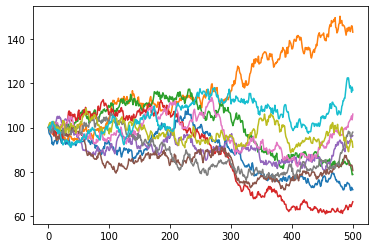

```
9.97994298084961
```

```python
if __name__ == '__main__':
    T = 1
    S0 = 100
    r = 0
    sigma1 = 0.25
    K = 100


    S_2 = path_generate2(S0, r, sigma1)
    plt.figure()
    plt.plot(S_2[:, :10])
    plt.show()


    #    payoff
    payoff2 = payoff2(K, S0, r, sigma1)


    average_discounted_payoff2 = payoff2/(1+r)**T
    price2 = np.mean(average_discounted_payoff2)
    print(price2)
```

##### (c) Calculate the price of the same European call option via the Black-Scholes formula. Is this price the same as you obtained via simulation? Should it be? Why or why not?

```python
    d1 = (np.log(S0 / K) + sigma1 ** 2 * T / 2) / (sigma1 * np.sqrt(T))
    d2 = (np.log(S0 / K) - sigma1 ** 2 * T / 2) / (sigma1 * np.sqrt(T))

    p = K * np.exp(-r * T) * norm.cdf(-d2) - S0 * norm.cdf(-d1)
    print(p)
```

```
9.94764496602258
```

The price is very close to each other

##### (d) In the Black-Scholes model, we know that the delta of a European call option is:

$$\Delta=\Phi(d_1)$$$$d_1=\dfrac{1}{\sigma\sqrt{T}}(ln\dfrac{S_0}{K}+(r+\dfrac{\sigma^2}{2})T)$$

##### Calculate the delta of an at-the-money European call option with one year to expiry

```python
    d1=1/(sigma1*np.sqrt(T))*(np.log(S0/K)+(r+sigma1**2/2)*T)
    delta=norm.cdf(d1,0,1)
    print(delta)
```

```
0.5497382248301129
```

##### (e) Using the delta obtained above, calculate how many shares of stock you need to construct a delta neutral portfolio that is long one unit of the call option and short ∆ shares of the stock?

The portfolio is long one call option and short 0.5497382248301129 shares of the stock

##### (f) Use simulation to estimate the payoff of the delta neutral portfolio obtained above. How does the payoff compare to the Black-Scholes model price of the option you obtained earlier? What conditions cause this portfolio to make money? Lose money?

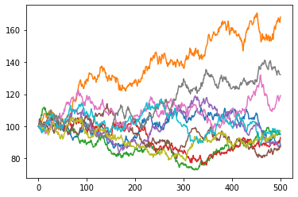

```
-45.546028668625866
```

```python
    a=port_path_generate(S0,r,sigma1,1,delta)
    print(a)
```

We lose money for it. The delta will change during the trading. So it make us lose the money.

##### (g) Modify the model dynamics so that β = 0:5 and all other parameters are the same as in the original question. Using the same hedging portfolio perform another simulation to estimate the payoffs of the delta-neutral portfolio under these dynamics. Are the payoffs higher or lower? Why?

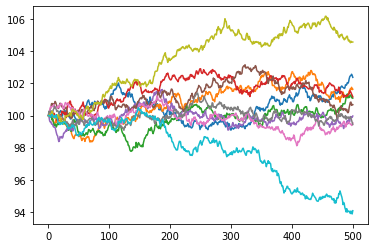

```
-53.95238848617502
```

```python
    b=port_path_generate(S0,r,sigma1,0.5,delta)
    print(b)
```

It is even more lower.

##### (h) Modify the model dynamics so that σ = 0:4 and all other parameters are the same as in the original question. Using the same hedging portfolio perform another simulation to estimate the payoffs of the delta-neutral portfolio under these dynamics. Explain the relationship between a delta-neutral portfolio and the σ parameter.

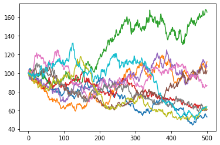

```
-39.152514687435804
```

```python
    c=port_path_generate(S0,r,0.4,1,delta)
    print(c)
```

It is a little better.